# Stat 159 Final Project - Providing Credit to Students

December 2, 2016

methods,results, analysis, conclusion, thank you slide

## Client Profile

## Client Profile

Our client is a credit institution that provides financial aid to students. The managers are interested in expanding their customer base but they would also like that most of the loans be payed back.

Main Question: What features and details of a school make it reliable for credit?

## Data

## Data

1. [College Scorecard](https://ed-public-download.apps.cloud.gov/downloads/CollegeScorecard_Raw_Data.zip): data on student completion, debt and repayment, earnings, and more. The files include data from 1996 through 2016 for all undergraduate degree-granting institutions of higher education. This data was last updated on September 13th, 2016.
2. [Post-school earnings](https://ed-public-download.apps.cloud.gov/downloads/Most-Recent-Cohorts-Treasury-Elements.csv): more current and detailed information about student post-school earnings for all undergraduate degree-granting institutions of higher education

Complete College Scorecard Data is available at https://collegescorecard.ed.gov/data/

Documentation on all data is available at https://collegescorecard.ed.gov/data/documentation/

## Methods

## Methods[1/2]

Response Variable: 3 Year Repayment Rate

1. Data Cleaning:
- replacing PrivacySuppressed columns with NULL
- Remove all columns with at least 50% NULL
- replace remaining NULL columns with column means
1. Variable Selection:
- Manually organize remaining columns by category to pick out variables relevant to research question
- Run correlation matrix on variables and select those with at least absolute value of .5 correlation to 3 year repayment rate

## Methods[2/2]

1. Regressions:
- Ordinary Least Squares Regression
- Lasso Regression
- Ridge Regression
- Principal Components Regression
- Partial Least Squares Regression
1. Time Series Analysis:
- Find data with 3 year repayment rate available
- Predict 3 year forecast based on the data available
- Find 100 school with highest projected mean 3 year repayment rates

## Results

## Visualizations

**Distribution of 3 Year Repayment Rate by Institution Type**

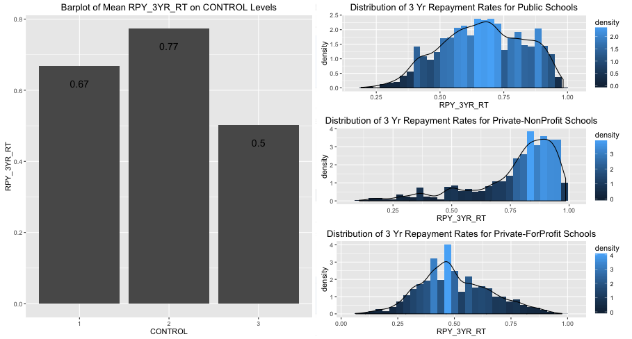

## Visualizations

**Distribution of 3 Year Repayment Rate by n Year Institutions**

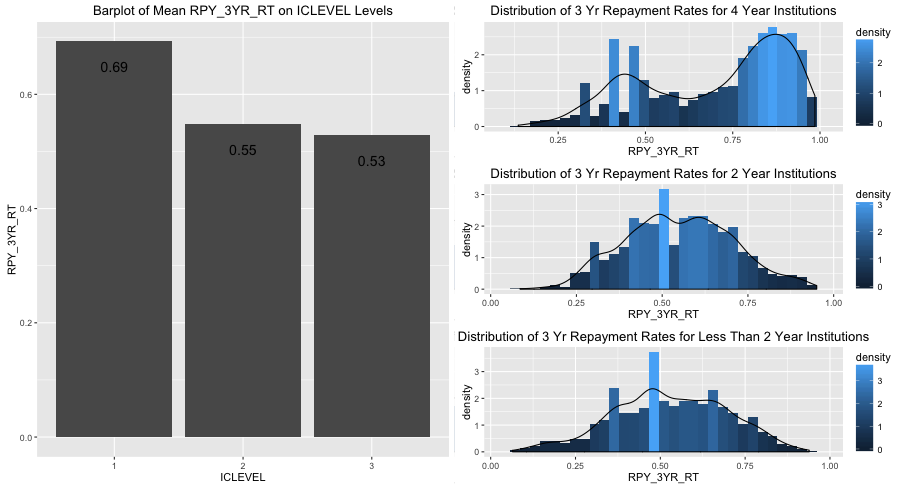

## Visualizations

**Scatter Plot: Completion Rate Rate vs. 3 Year Repayment Rate**

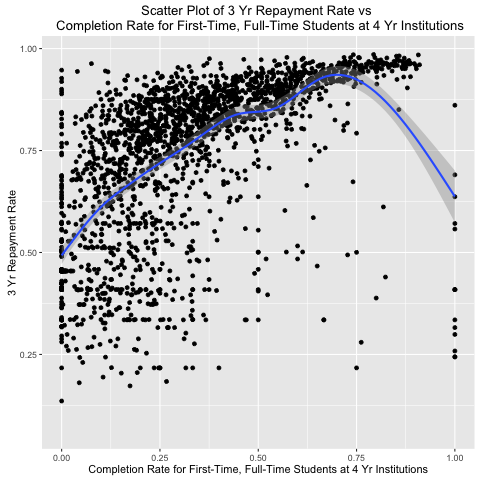

## Visualizations

**Scatter Plot: Net Price for Institution Type vs. 3 Year Repayment Rate**

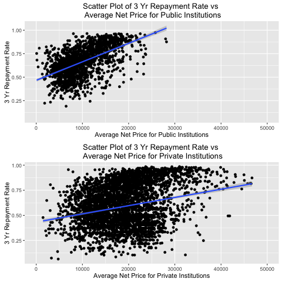

## Table 1:Predictors with high correlation

| Variable | Correlation.Value |
| --- | --- |
| INC_PCT_H1 | 0.8199 |
| INC_PCT_H2 | 0.7633 |
| INC_PCT_M2 | 0.7621 |
| C200_4_POOLED_SUPP | 0.7188 |
| MN_EARN_WNE_INC1_P6 | 0.6536 |
| C150_4_POOLED_SUPP | 0.6486 |
| PCT25_EARN_WNE_P6 | 0.6478 |
| PCT10_EARN_WNE_P6 | 0.6456 |
| GT_25K_P6 | 0.6367 |
| C150_4 | 0.6158 |
| MD_EARN_WNE_P6 | 0.609 |
| NPT4_75UP_PUB | 0.6072 |
| MN_EARN_WNE_P6 | 0.5874 |
| TUITIONFEE_OUT | 0.5823 |
| PCT75_EARN_WNE_P6 | 0.5742 |
| C150_4_WHITE | 0.567 |
| NPT4_PUB | 0.5605 |
| C100_4 | 0.557 |
| PAR_ED_PCT_1STGEN | -0.7109 |
| CDR3 | -0.7504 |
| INC_PCT_LO | -0.8347 |

## Table 2: MSE of regressions

| OLS | Lasso | Ridge | PCR | PLSR |
| --- | --- | --- | --- | --- |
| 0.04325 | 0.01519 | 0.01504 | 0.01507 | 0.01506 |

## Table 3: Ridge Coefficients

|  | Coefficients |
| --- | --- |
| **INC_PCT_M2** | 0.02188 |
| **C150_4_POOLED_SUPP** | 0.01286 |
| **PCT10_EARN_WNE_P6** | 2.079e-07 |
| **GT_25K_P6** | 0.007406 |
| **C150_4** | 0.01102 |
| **NPT4_75UP_PUB** | 9.26e-07 |
| **TUITIONFEE_OUT** | 1.049e-07 |

## Regression Results

**Interpretation of Ridge regression coefficients**

## Table 4: Top 8 Schools

|  | INSTNM | row_mean |
| --- | --- | --- |
| **443331** | West Coast University-Los Angeles | 1 |
| **167996** | Stonehill College | 0.9936 |
| **217165** | Bryant University | 0.9924 |
| **213251** | Juniata College | 0.9909 |
| **177719** | Barnes-Jewish College Goldfarb School of Nursing | 0.9892 |
| **211440** | Carnegie Mellon University | 0.9856 |
| **239716** | Saint Norbert College | 0.9824 |
| **152080** | University of Notre Dame | 0.9792 |

## Conclusion

## Conclusion

We believe that repayment rates on federal loans will likely be correlated with the same factors as repayment rates on private loans, so these factors are good predictors of the schools in which our client should offer loans.